# Artigo – Tópicos de Teses e Dissertações em Nutrição (27/07/2026)

## 1 Metodologia

Dados importados da Plataforma Dados Abertos da CAPES - Grupo: Catálogo de Teses e Dissertações.

Período: 2011 a 2024

N: 976.217

Seleção: Código de Área da Nutrição (CD_AREA_CONHECIMENTO (40500004)) n: 5.738 trabalhos

### 1.1 Filtros

1. Programa (25001019075P0) (n: 30)
2. Mestrado Profissional: NM_GRAU_ACADEMICO (n: 325)
3. RESUMOS INSUFICIENTES (<50 palavras) (n:96)
4. RESUMOS EM INGLÊS E OUTROS IDIOMAS (n:10)

TOTAL: n:5.281

### 1.2 Descrição do Banco

Tabela 1

| Categoria | n |
| --- | --- |
| Grau Acadêmico |  |
| MESTRADO | 4294 |
| DOUTORADO | 987 |
| Região |  |
| SUDESTE | 2237 |
| NORDESTE | 1665 |
| SUL | 760 |
| CENTRO-OESTE | 619 |
| Ano (Top 5) |  |
| 2023 | 529 |
| 2024 | 513 |
| 2021 | 466 |
| 2020 | 431 |
| 2019 | 426 |
| IES (Top 5) |  |
| UNIVERSIDADE FEDERAL DE PERNAMBUCO (CAV) | 385 |
| UNIVERSIDADE FEDERAL DE VIÇOSA | 354 |
| UNIVERSIDADE FEDERAL DO RIO DE JANEIRO | 339 |
| UNIVERSIDADE FEDERAL DE SÃO PAULO | 300 |
| UNIVERSIDADE DO ESTADO DO RIO DE JANEIRO | 269 |

### 1.3 Limpeza de texto

Transformações do texto:

1. caixa baixa
2. retirada de pontuações e símbolos especiais
3. retirada de stopwords padrão da língua portugues
4. substitução de expressões separadas por ngrams (bi-, tri- e tetragrams)
5. remoção de números e palavras com menos de 2 caracteres
6. remoção de stopwords cientíticas

### 1.4 Modelo STM

**Breves definições:**

Documento: unidade de análise (resumo de tese ou dissertação).

Tópico: Distribuição probabilística de palavras que representa um tema latente no *corpus*. Cada documento possui uma combinação de múltiplos tópicos em diferentes proporções.

Medida Beta (β): Probabilidade de uma palavra ocorrer em determinado tópico.

FREX (Frequent and Exclusive): Métrica que combina frequência de uma palavra com sua exclusividade com relação aos demais tópicos.

Medida Gamma (γ): Proporção estimada de cada tópico em um documento.

Abaixo, segue gráfico com os 30 tópicos mais pesquisados. A medida gamma indica a prevalência média do tópico no *corpus* inteiro. Por exemplo, 3.3% do Tópico 52 não deve ser interpretado como 3.3% dos trabalhos (teses e dissertações), mas 3.3% de todo o texto do *corpus*.

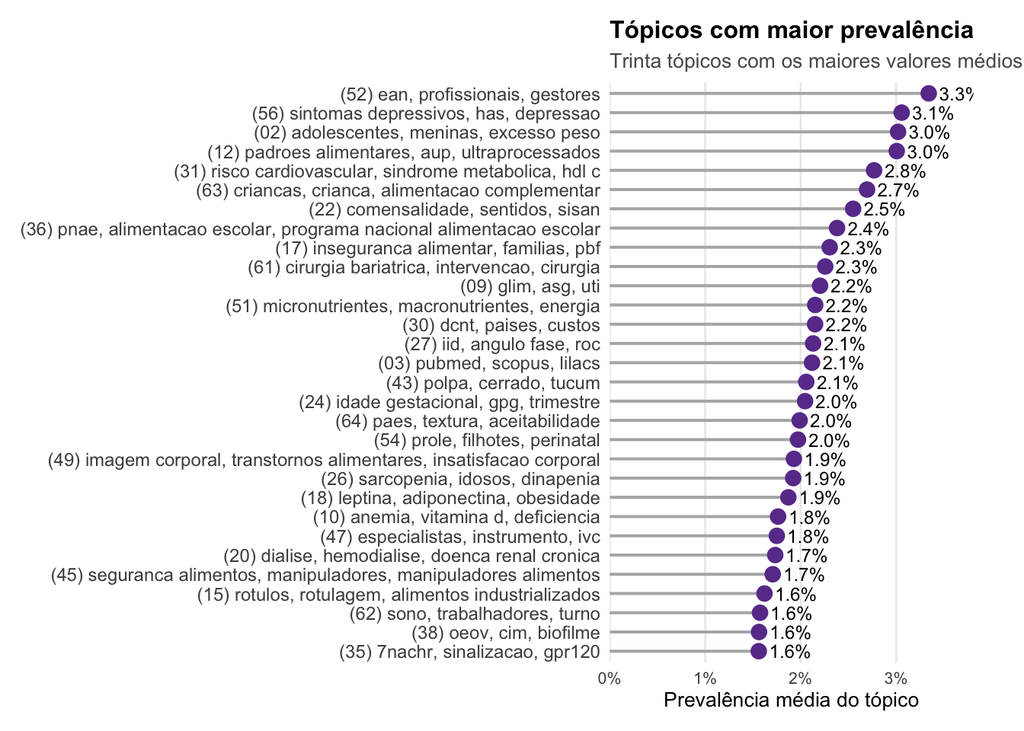

Abaixo, segue a tabela integral com todos os tópicos.

**Modelo de 65 Tópicos**

Ordenados pela prevalência média (γ)

| Tópico | Palavras FREX | γ médio |
| --- | --- | --- |
| 52 | ean, profissionais, gestores | 0.033 |
| 56 | sintomas depressivos, has, depressao | 0.031 |
| 2 | adolescentes, meninas, excesso peso | 0.030 |
| 12 | padroes alimentares, aup, ultraprocessados | 0.030 |
| 31 | risco cardiovascular, sindrome metabolica, hdl c | 0.028 |
| 63 | criancas, crianca, alimentacao complementar | 0.027 |
| 22 | comensalidade, sentidos, sisan | 0.025 |
| 36 | pnae, alimentacao escolar, programa nacional alimentacao escolar | 0.024 |
| 17 | inseguranca alimentar, familias, pbf | 0.023 |
| 61 | cirurgia bariatrica, intervencao, cirurgia | 0.023 |
| 9 | glim, asg, uti | 0.022 |
| 51 | micronutrientes, macronutrientes, energia | 0.022 |
| 30 | dcnt, paises, custos | 0.022 |
| 27 | iid, angulo fase, roc | 0.021 |
| 3 | pubmed, scopus, lilacs | 0.021 |
| 43 | polpa, cerrado, tucum | 0.021 |
| 24 | idade gestacional, gpg, trimestre | 0.020 |
| 64 | paes, textura, aceitabilidade | 0.020 |
| 54 | prole, filhotes, perinatal | 0.020 |
| 49 | imagem corporal, transtornos alimentares, insatisfacao corporal | 0.019 |
| 26 | sarcopenia, idosos, dinapenia | 0.019 |
| 18 | leptina, adiponectina, obesidade | 0.019 |
| 10 | anemia, vitamina d, deficiencia | 0.018 |
| 47 | especialistas, instrumento, ivc | 0.018 |
| 20 | dialise, hemodialise, doenca renal cronica | 0.017 |
| 45 | seguranca alimentos, manipuladores, manipuladores alimentos | 0.017 |
| 15 | rotulos, rotulagem, alimentos industrializados | 0.016 |
| 62 | sono, trabalhadores, turno | 0.016 |
| 38 | oeov, cim, biofilme | 0.016 |
| 35 | 7nachr, sinalizacao, gpr120 | 0.016 |
| 39 | qualidade vida, qvrs, disfagia | 0.016 |
| 58 | ultrassom, secagem, extracao | 0.016 |
| 34 | qualidade dieta, pontuacao, iqd | 0.015 |
| 53 | dmo, tmb, equacoes | 0.015 |
| 33 | exaustao, cafeina, pla | 0.014 |
| 37 | cha verde, diabeticos, stz | 0.014 |
| 11 | ambiente alimentar, entorno, estabelecimentos | 0.013 |
| 29 | linhaca, oleo coco, virgem | 0.013 |
| 8 | fermentacao, probioticas, casei | 0.013 |
| 21 | catd, sod, estresse oxidativo | 0.013 |
| 19 | prandial, ccm, ages | 0.012 |
| 14 | tomate, coco, bico | 0.011 |
| 5 | adipocitos, inguinal, tam | 0.011 |
| 6 | cho, prova, desempenho | 0.011 |
| 59 | snp, snps, alelos | 0.011 |
| 28 | simbiotico, microbiota intestinal, intestinal | 0.010 |
| 25 | shr, doses, emax | 0.010 |
| 57 | pandemia, sars, pandemia covid 19 | 0.010 |
| 7 | restricao proteica, ilhotas, ovx | 0.010 |
| 32 | dac, cortical, memoria | 0.009 |
| 42 | oleo peixe, capsulas, suplementacao | 0.009 |
| 4 | jogadores, jogos, sessao | 0.009 |
| 44 | mcf, ecv, propolis | 0.009 |
| 41 | encapsulacao, nanoparticulas, microparticulas | 0.008 |
| 46 | caprino, vaca, leite | 0.008 |
| 16 | tocoferol, agpi, caroteno | 0.008 |
| 23 | kefir, treinamento fisico, resistido | 0.008 |
| 60 | placenta, mir, placentario | 0.007 |
| 40 | chia, brs, sorgo | 0.007 |
| 13 | hiperalgesia, parkin, dor | 0.006 |
| 1 | mthfr, metilacao, hipertensas | 0.006 |
| 55 | piperina, mdr, h2o2 | 0.006 |
| 48 | dm1, silico, s6ks | 0.005 |
| 50 | uva, vinhos, polifenois | 0.005 |
| 65 | gostos, gustativa, amargo | 0.001 |

### 1.5 Gráfico com palavras mais frequentes (β)

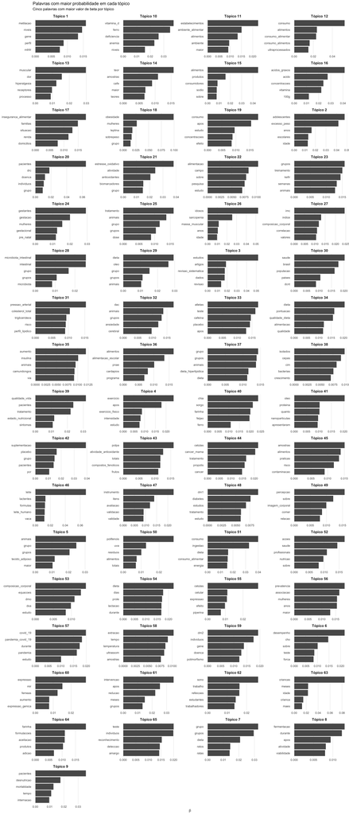

### 1.6 Efeito ano

Para estimar a prevalência dos tópicos ao longo do tempo, a covariável ano foi incorporada ao componente de prevalência do modelo. Isso permite estimar como a prevalência esperada de cada tópico varia em função do ano.

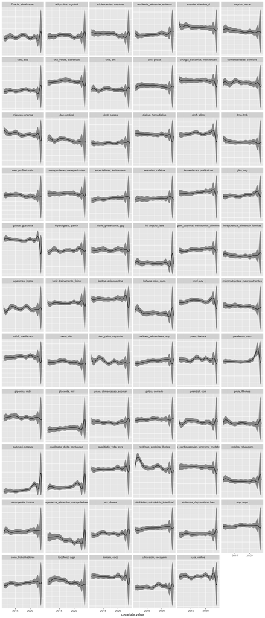